# Soil fungi underlie a phylogenetic pattern in plant growth responses to nitrogen enrichment - Random Forests

Let’s look at more Fungi…. https://datadryad.org/stash/dataset/doi:10.5061%2Fdryad.m0ks82k https://datadryad.org/stash/dataset/doi:10.5061/dryad.m0ks82k https://besjournals.onlinelibrary.wiley.com/doi/10.1111/1365-2745.12983

1. Under increasing anthropogenic nitrogen (N) deposition, some plant species will thrive while others will not. Previous work has shown that plant phylogeny can predict these responses, and that interactions with mycorrhizal fungi are a mechanism that drives variation in plant responses to N enrichment. Yet, much of this work has ignored the roles of other root-associated fungi and whole soil fungal communities in driving these responses.
2. We tested whether soil fungi mediate responses of plant growth and plant-soil feedbacks (between close and distant plant relatives) to N enrichment by implementing a greenhouse experiment in which we applied factorial treatments of N fertilization, host-specific soil inocula, and fungicide to 15 eucalypt tree species that co-occur on the island state of Tasmania, Australia and form two phylogenetic lineages within the subgenus Symphyomyrtus.
3. Conspecific-conditioned soil fungi enhanced growth responses to N enrichment for plants within one lineage (lineage 1) but depressed growth responses to N enrichment for plants within another lineage (lineage 2). Lineage-specific shifts in ectomycorrhizal (ECM) colonization were consistent with previous evidence that more vs. less successful strategies under N enrichment are those where carbon allocation to mycorrhizal fungi is reduced vs. maintained, respectively. The latter was also accompanied by a stronger reduction in root colonization of non-filamentous fungi (of unknown function) under N enrichment. Plant-soil feedbacks were neutral for lineage 1 but negative for lineage 2 (i.e., greater growth in soils conditioned by opposite vs. same lineage individuals), but were not altered by N enrichment or fungicide. Lineage-level differences in root colonization suggest that these feedbacks could be driven by differential plant responsiveness to dark septate endophytes and non-filamentous fungi, the colonization of which seemed to benefit plant growth.
4. Our results confirm that interactions with soil fungi (ECM fungi in particular) underlie phylogenetic patterns in tree species’ growth responses to N enrichment and may thus influence which plants win or lose under future N deposition scenarios. Yet, we provide some of the first evidence (albeit from controlled rather than natural conditions) that N deposition may not play a strong role in shifting plant-soil feedbacks.

```r
# install.packages("RPostgreSQL")
require("RPostgreSQL")

# Load the PostgreSQL driver, create a connection to the postgres database
drv <- dbDriver("PostgreSQL")
con <- dbConnect(drv, dbname = "nitrofungi", host = "localhost", port = 5432, user = "ruser", password = "ruser")

sequencing_sql_string <- paste("SELECT * FROM sequencing", sep="")
greenhouse_sql_string <- paste("SELECT * FROM greenhouse", sep="")
```

So I’d been looking for things with which to do anything with but could only find a bunch of ‘Do these factors contribute to this?’. Which I guess is everything…?

My limited understanding of the Random Forests algorythm tells me that’s the perfect question for random forests.

So we have 2 data frames with which to work with.

```r
sequencing <- data.frame(dbGetQuery(con, sequencing_sql_string))
greenhouse <- data.frame(dbGetQuery(con, greenhouse_sql_string))

head(sequencing)
```

|  | num | denovo | e_archeri | e_barberi | e_brookeriana | e_cordata | e_dalrympleana | e_globulus | e_gunnii | e_johnstonii | e_morrisbyi | e_ovata | e_perriniana | e_rodwayi | e_rubida | e_subcrenulata | e_urnigera | e_viminalis | taxonomy | trophic_mode | guild | pathogen_type | plant_host | citation | growth_morphology | taxon | taxon_level | confidence_ranking | trait |
| --- | --- | --- | --- | --- | --- | --- | --- | --- | --- | --- | --- | --- | --- | --- | --- | --- | --- | --- | --- | --- | --- | --- | --- | --- | --- | --- | --- | --- | --- |
| 1 | 1 | denovo30 | 0.184015595 | 0.060428850 | 0.04444444 | 0.024561404 | 0.020467836 | 0.03333333 | 0.061208577 | 0.018128655 | 0.048148148 | 0.026315789 | 0.023196881 | 0.048343080 | 0.02592593 | 0.02982456 | 0.03781676 | 0.031384016 | k__Fungi; p__Basidiomycota; c__Tremellomycetes; o__Tremellales; f__Incertae sedis; g__Cryptococcus; s__Cryptococcus podzolicus | Pathotroph-Saprotroph | Animal Pathogen-Saprotroph |  |  |  | Yeast | Cryptococcus | 13 | Highly Probable | NULL |
| 2 | 2 | denovo3 | 0.006432749 | 0.023391813 | 0.01384016 | 0.021442495 | 0.012085770 | 0.02962963 | 0.000974659 | 0.009356725 | 0.024366472 | 0.013060429 | 0.026120858 | 0.129239766 | 0.01676413 | 0.09551657 | 0.01286550 | 0.089473684 | k__Fungi; p__Zygomycota; c__Incertae sedis; o__Mortierellales; f__Mortierellaceae; g__Mortierella; s__Mortierella sp | Saprotroph | Undefined Saprotroph |  |  |  | NULL | Mortierella | 13 | Probable | NULL |
| 3 | 3 | denovo68 | 0.014035088 | 0.020467836 | 0.01559454 | 0.031384016 | 0.032748538 | 0.04502924 | 0.054385965 | 0.027680312 | 0.024561404 | 0.027095517 | 0.003508772 | 0.004678363 | 0.03586745 | 0.04697856 | 0.01325536 | 0.055750487 | k__Fungi; p__Zygomycota; c__Incertae sedis; o__Mortierellales; f__Mortierellaceae; g__Mortierella; s__Mortierella sp | Saprotroph | Undefined Saprotroph |  |  |  | NULL | Mortierella | 13 | Probable | NULL |
| 4 | 4 | denovo200 | 0.012865497 | 0.046783626 | 0.00994152 | 0.005263158 | 0.009551657 | 0.00877193 | 0.013450292 | 0.078752437 | 0.011890838 | 0.008576998 | 0.013450292 | 0.016764133 | 0.04366472 | 0.01461988 | 0.04639376 | 0.014230019 | k__Fungi; p__Ascomycota; c__Sordariomycetes; o__Sordariales; f__Chaetomiaceae; g__Chaetomium; s__Chaetomium bostrychodes | Saprotroph | Dung Saprotroph-Undefined Saprotroph-Wood Saprotroph |  |  |  | NULL | Chaetomium | 13 | Highly Probable | Soft Rot |
| 5 | 5 | denovo151 | 0.026120858 | 0.028070175 | 0.01578947 | 0.000974659 | 0.015984405 | 0.02768031 | 0.025925926 | 0.021832359 | 0.001364522 | 0.013255361 | 0.011111111 | 0.003898635 | 0.08518518 | 0.01656920 | 0.05633528 | 0.001949318 | k__Fungi; p__Zygomycota; c__Incertae sedis; o__Mortierellales; f__Mortierellaceae; g__Mortierella; s__Mortierella sp | Saprotroph | Undefined Saprotroph |  |  |  | NULL | Mortierella | 13 | Probable | NULL |
| 6 | 6 | denovo278 | 0.015399610 | 0.007992203 | 0.02202729 | 0.018323587 | 0.011695906 | 0.03430799 | 0.028265107 | 0.014230019 | 0.012475634 | 0.030214425 | 0.020467836 | 0.010136452 | 0.02904483 | 0.02085770 | 0.02982456 | 0.024756335 | k__Fungi; p__Ascomycota; c__Eurotiomycetes; o__Chaetothyriales; f__Herpotrichiellaceae; g__Exophiala; s__Exophiala equina | Saprotroph | Undefined Saprotroph |  |  |  | Facultative Yeast | Exophiala | 13 | Probable | NULL |

```r
head(greenhouse)
```

|  | pot | species | lineage | soil | nitrogen | fungi | block | height | biomass | number_of_roots_colonized_by_ecm_fungi | number_of_roots_colonized_by_am_fungi | number_of_roots_colonized_by_dse_fungi | number_of_roots_colonized_by_nonfilamentous_fungi |
| --- | --- | --- | --- | --- | --- | --- | --- | --- | --- | --- | --- | --- | --- |
| 1 | 1 | E. barberi | 1 | control | low N | live | 1 | 19 | 0.51786 | 39 | 0 | 0 | 35 |
| 2 | 2 | E. barberi | 1 | control | low N | live | 2 | 34 | 2.76370 | 15 | 0 | 3 | 36 |
| 3 | 3 | E. barberi | 1 | control | low N | live | 3 | 43 | 1.98060 | 34 | 0 | 0 | 45 |
| 4 | 4 | E. barberi | 1 | control | low N | live | 4 | 38 | 1.35120 | 0 | 0 | 0 | 0 |
| 5 | 5 | E. barberi | 1 | control | low N | fungicide | 1 | 56 | 3.35660 | 8 | 0 | 0 | 1 |
| 6 | 6 | E. barberi | 1 | control | low N | fungicide | 2 | 58 | 12.20130 | 0 | 0 | 3 | 18 |

So now we need to run random trees

```r
#install.packages("randomForest")
library(randomForest)

set.seed(1026)

barberi <- subset(greenhouse, greenhouse$species == "E. barberi")

forest0 <- randomForest(barberi$biomass ~ barberi$number_of_roots_colonized_by_ecm_fungi)
forest1 <- randomForest(barberi$biomass ~ barberi$number_of_roots_colonized_by_am_fungi)
forest2 <- randomForest(barberi$biomass ~ barberi$number_of_roots_colonized_by_dse_fungi)
forest3 <- randomForest(barberi$biomass ~ barberi$number_of_roots_colonized_by_nonfilamentous_fungi)
forest4 <- randomForest(barberi$height ~ barberi$biomass)
forest5 <- randomForest(barberi$biomass ~ barberi$height)

forest0
```

```
Call:
 randomForest(formula = barberi$biomass ~ barberi$number_of_roots_colonized_by_ecm_fungi)
               Type of random forest: regression
                     Number of trees: 500
No. of variables tried at each split: 1

          Mean of squared residuals: 10.92517
                    % Var explained: -32.69
```

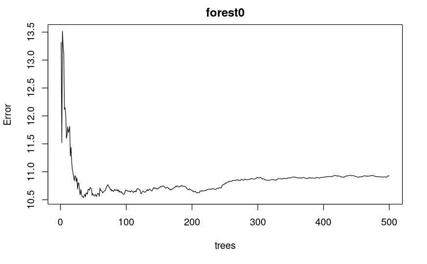

```r
plot(forest0)
```

```r
forest1
```

```
Call:
 randomForest(formula = barberi$biomass ~ barberi$number_of_roots_colonized_by_am_fungi)
               Type of random forest: regression
                     Number of trees: 500
No. of variables tried at each split: 1

          Mean of squared residuals: 8.527742
                    % Var explained: -3.57
```

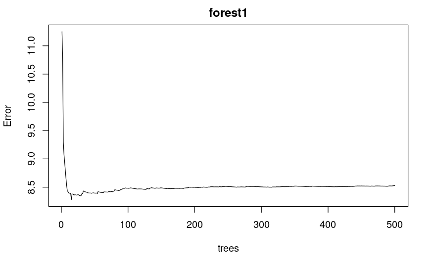

```r
plot(forest1)
```

```r
forest2
```

```
Call:
 randomForest(formula = barberi$biomass ~ barberi$number_of_roots_colonized_by_dse_fungi)
               Type of random forest: regression
                     Number of trees: 500
No. of variables tried at each split: 1

          Mean of squared residuals: 8.848536
                    % Var explained: -7.47
```

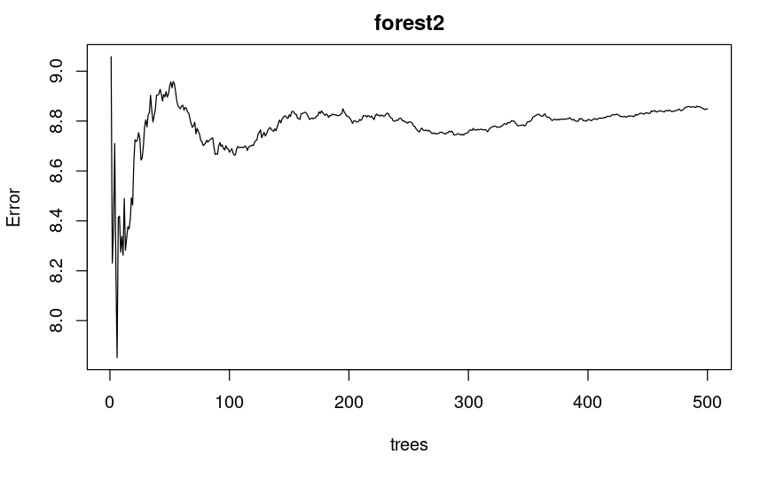

```r
plot(forest2)
```

```r
forest3
```

```
Call:
 randomForest(formula = barberi$biomass ~ barberi$number_of_roots_colonized_by_nonfilamentous_fungi)
               Type of random forest: regression
                     Number of trees: 500
No. of variables tried at each split: 1

          Mean of squared residuals: 10.71451
                    % Var explained: -30.13
```

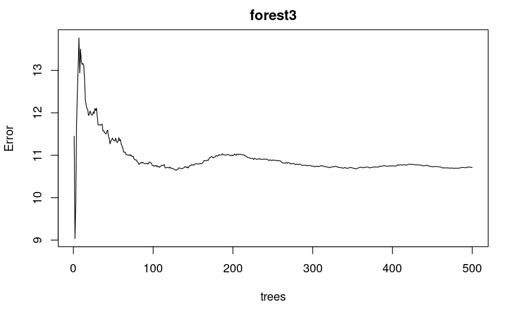

```r
plot(forest3)
```

```r
forest4
```

```
Call:
 randomForest(formula = barberi$height ~ barberi$biomass)
               Type of random forest: regression
                     Number of trees: 500
No. of variables tried at each split: 1

          Mean of squared residuals: 128.4309
                    % Var explained: 49.36
```

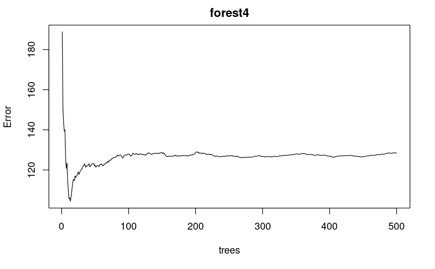

```r
plot(forest4)
```

```r
forest5
```

```
Call:
 randomForest(formula = barberi$biomass ~ barberi$height)
               Type of random forest: regression
                     Number of trees: 500
No. of variables tried at each split: 1

          Mean of squared residuals: 5.689501
                    % Var explained: 30.9
```

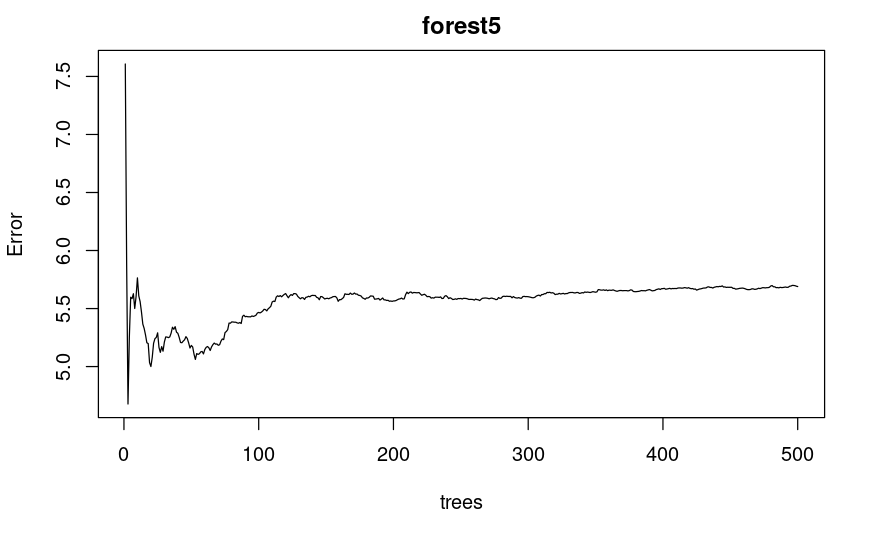

```r
plot(forest5)
```

Is that it? Is that random forests? Is the only thing left now interpretation?

```r
#install.packages("randomForest")
library(randomForest)
set.seed(1026)

#only nitrogen
brookeriana <- subset(greenhouse, greenhouse$species == "E. brookeriana")
brookertree <- randomForest(brookeriana$biomass ~ as.factor(brookeriana$nitrogen), na.action = na.exclude)

brookertree
```

```
Call:
 randomForest(formula = brookeriana$biomass ~ as.factor(brookeriana$nitrogen),      na.action = na.exclude)
               Type of random forest: regression
                     Number of trees: 500
No. of variables tried at each split: 1

          Mean of squared residuals: 22.92886
                    % Var explained: -1.72
```

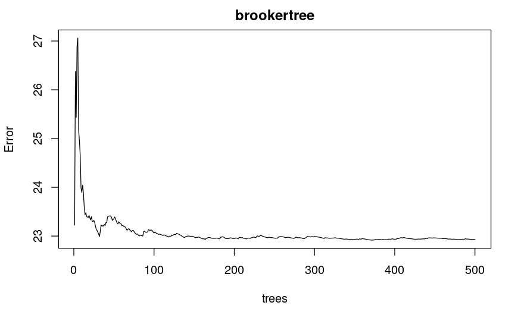

```r
plot(brookertree)
```

That just calls for interpretation, right?

```r
#install.packages("randomForest")
library(randomForest)
set.seed(1026)

#with nitrogen
gunnii <- subset(greenhouse, greenhouse$species == "E. gunnii")
gunniitree <- randomForest(gunnii$biomass ~ as.factor(gunnii$nitrogen) +
                             barberi$number_of_roots_colonized_by_ecm_fungi +
                             barberi$number_of_roots_colonized_by_am_fungi +
                             barberi$number_of_roots_colonized_by_dse_fungi +
                             barberi$number_of_roots_colonized_by_nonfilamentous_fungi, na.action = na.exclude)

gunniitree
```

```
Call:
 randomForest(formula = gunnii$biomass ~ as.factor(gunnii$nitrogen) +      barberi$number_of_roots_colonized_by_ecm_fungi + barberi$number_of_roots_colonized_by_am_fungi +      barberi$number_of_roots_colonized_by_dse_fungi + barberi$number_of_roots_colonized_by_nonfilamentous_fungi,      na.action …
               Type of random forest: regression
                     Number of trees: 500
No. of variables tried at each split: 1

          Mean of squared residuals: 9.182063
                    % Var explained: 2.23
```

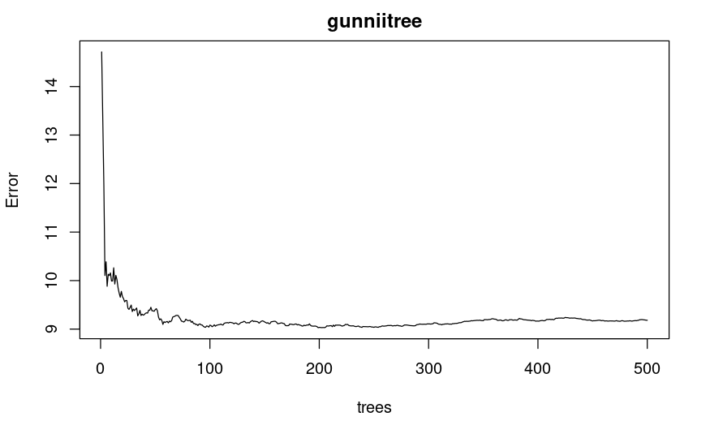

```r
plot(gunniitree)
```

```r
#Without nitrogen factored in.
gunnii <- subset(greenhouse, greenhouse$species == "E. gunnii")
ngunniitree <- randomForest(gunnii$biomass ~ barberi$number_of_roots_colonized_by_ecm_fungi +
                             barberi$number_of_roots_colonized_by_am_fungi +
                             barberi$number_of_roots_colonized_by_dse_fungi +
                             barberi$number_of_roots_colonized_by_nonfilamentous_fungi, na.action = na.exclude)

ngunniitree
```

```
Call:
 randomForest(formula = gunnii$biomass ~ barberi$number_of_roots_colonized_by_ecm_fungi +      barberi$number_of_roots_colonized_by_am_fungi + barberi$number_of_roots_colonized_by_dse_fungi +      barberi$number_of_roots_colonized_by_nonfilamentous_fungi,      na.action = na.exclude)
               Type of random forest: regression
                     Number of trees: 500
No. of variables tried at each split: 1

          Mean of squared residuals: 8.921316
                    % Var explained: 5
```

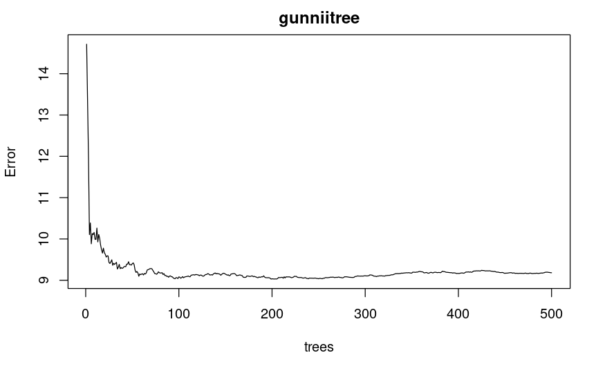

```r
plot(gunniitree)
```